# Practical Machine Learning Course Project

Shawn W. Foley

10/28/2020

## Summary

The goal of this project is to generate a machine learning model to identify the "Class" of exercise performed from collected biometric data. After filtering and scaling, I generated random forest (RF), boosting (GBM), and linear discriminte analysis (LDA) models using all remaining variables. As accuracy, but not scalability, is the goal of this project I used these models to generate a stacked machine learning model.

Cross validation was performed by splitting the data into a training and validation set. Z normalization was performed on the training set, and the measured mean and standard deviation were used to scale the validation set. The normalized validation data were analyze by each of the four models (RF, GBM, LDA, and stacked) and out of sample error was estimated for each model.

I consistently found higher accuracy using the training data than the validation data, as expected. Both the RF and stacked models have identically high accuracy (>99%) and low expected out of sample error (<1%), indicating that the GBM and LDA models do **not** increase accuracy over the RF model alone.

### Stratify and preprocess data

I began this analysis by loading the plm-training.csv file and found 19,622 observations across 160 variables. As there are a large number of observations, I chose to split the data to perform cross validation. I randomly divided the observations into a training (70%) and validation set (30%).

```r
#Load data and stratify into training and validating sets
library(caret)
```

```r
library(ggplot2)
set.seed(1020)
exerciseData <- read.csv('~/Desktop/Coursera/Practical Machine Learning/pml-training.csv')

#Create training set
inTrain <- createDataPartition(exerciseData$classe,p=0.7,list=FALSE)
training <- exerciseData[inTrain,]
validating <- exerciseData[-inTrain,]
```

Several of these variables correspond to metadata that are likely uninformative (timestamps and time windows). These variables were removed, and the remaining string values were converted to factors for analysis.

```r
#Remove metadata columns and set numeric and factor
training <- training[,-which(colnames(training) %in% c('X','raw_timestamp_part_1','raw_timestamp_part_2','cvtd_timestamp','new_window'))]
training <- training[,c(1,ncol(training),seq(2,ncol(training)-1))]
training[,-seq(2)] <- apply(training[,-seq(2)],2,as.numeric)
training[,seq(2)] <- apply(training[,seq(2)],2,factor)
```

```r
#Generate Z score
trainingMean <- apply(training[,-seq(2)],2,function(x) mean(x,na.rm=T))
trainingSD <- apply(training[,-seq(2)],2,function(x) sd(x,na.rm=T))
trainingZ <- NULL
for (i in seq(3,ncol(training))) {
  trainingZ <- cbind(trainingZ,(training[,i] - trainingMean[i-2]) / trainingSD[i-2])
}
colnames(trainingZ) <- colnames(training)[-seq(2)]
trainingZ.noNA <- trainingZ[,colSums(is.na(trainingZ)) == 0]
```

### PCA plot

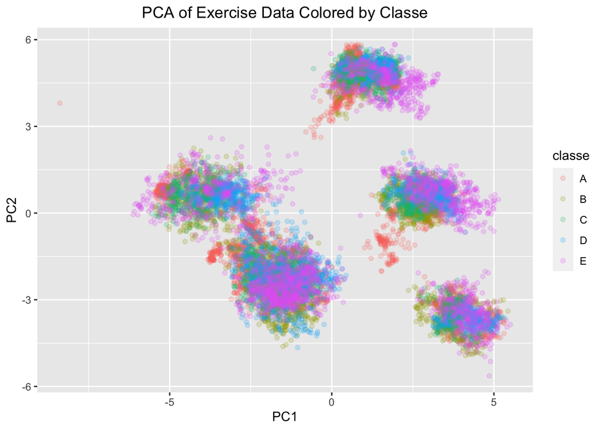

```r
pca <- as.data.frame(prcomp(trainingZ.noNA)$x)
pca$classe <- training$classe
pca$user_name <- training$user_name
ggplot(pca,aes(x=PC1,y=PC2,col=classe)) + geom_point(alpha=0.2) +
  ggtitle("PCA of Exercise Data Colored by Classe") +
  theme(plot.title = element_text(hjust = 0.5))
```

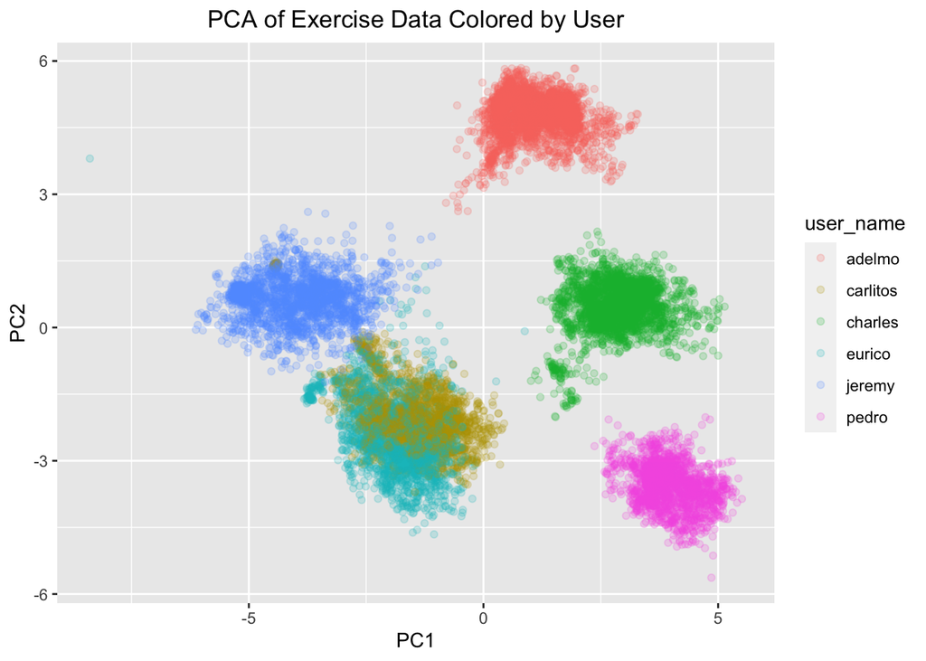

```r
ggplot(pca,aes(x=PC1,y=PC2,col=user_name)) + geom_point(alpha=0.2) +
  ggtitle("PCA of Exercise Data Colored by User") +
  theme(plot.title = element_text(hjust = 0.5))
```

### Model building

The class and username were re-added to the normalized data, and several machine learning models were built. Random forest, boosting, and linear discriminate analysis models were generated, and a data frame of predicted outcomes for each model was compiled. As the goal of this project is accuracy rather than scalability, a stacked prediction model was generated. Random forest is often considered one of the most accurate machine larning methods, therefore these models were used as input to build a stacked model using random forest.

```r
training.norm <- as.data.frame(cbind(training$classe,training$user_name,trainingZ.noNA))
colnames(training.norm)[seq(2)] <- c('classe','user_name')
training.norm[,-seq(2)] <- apply(training.norm[,-seq(2)],2,as.numeric)

#Build ML models
rf <- train(classe ~ .,data=training.norm,method='rf')
gbm <- train(classe ~ .,data=training.norm,method='gbm')
lda <- train(classe ~ .,data=training.norm,method='lda')

#Build stacked model
pred.train <- data.frame(rf=predict(rf,training.norm),gbm=predict(gbm,training.norm),lda=predict(lda,training.norm),classe=training.norm$classe)
stackedModel <- train(classe ~ .,data=pred.train,method='rf')
```

The accuracy of the four models (three individual and stacked) was then calculated.

```r
#Find accuracy of models
trainingAcc <- c(
  `Random Forest` = confusionMatrix(pred.train$rf,training.norm$classe)$overall['Accuracy'],
  `Boosting` = confusionMatrix(pred.train$gbm,training.norm$classe)$overall['Accuracy'],
  `LDA` = confusionMatrix(pred.train$lda,training.norm$classe)$overall['Accuracy'],
    Stacked=confusionMatrix(predict(stackedModel,pred.train),pred.train$classe)$overall['Accuracy'])
print(trainingAcc)
```

```
## Random Forest.Accuracy      Boosting.Accuracy           LDA.Accuracy
##              1.0000000              0.9944675              0.7502366
##       Stacked.Accuracy
##              1.0000000
```

The random forest and stacked models perfectly assign the exercise class (accuracy = 1.0), indicating potential overfitting. To estimate the out of sample error, these models were tested on the validation dataset.

### Validation and out of sample error

To estimate out of sample error, I ran the machine learning models on the validation dataset. The validation data underwent the same processing as the training data: 1. Metadata columns were removed. 2. Variables with NAs were removed. 3. Validation data was Z normalized using mean and standard deviation from the training set.

```r
#Remove metadata columns from validation data and convert variables to numeric/factor
validating <- validating[,-which(colnames(validating) %in% c('X','raw_timestamp_part_1','raw_timestamp_part_2','cvtd_timestamp','new_window'))]
validating <- validating[,c(1,ncol(validating),seq(2,ncol(validating)-1))]
validating[,-seq(2)] <- apply(validating[,-seq(2)],2,as.numeric)
validating[,seq(2)] <- apply(validating[,seq(2)],2,factor)

#Z normalize using mean and SD from training set
v <- NULL
for (i in seq(3,ncol(validating))) {
  v <- cbind(v,(validating[,i] - trainingMean[i-2]) / trainingSD[i-2])
}
colnames(v) <- colnames(validating)[-seq(2)]
v.noNA <- v[,colSums(is.na(v)) == 0]
v.norm <- as.data.frame(cbind(validating$classe,validating$user_name,v.noNA))
colnames(v.norm)[seq(2)] <- c('classe','user_name')
v.norm[,-seq(2)] <- apply(v.norm[,-seq(2)],2,as.numeric)

#Data frame of predicted classes from random forest, boosting, and LDA models
pred.val <- data.frame(rf=predict(rf,v.norm),gbm=predict(gbm,v.norm),lda=predict(lda,v.norm),classe=v.norm$classe)

#Accuracy values from all four models
valAcc <- c(
  `Random Forest` = confusionMatrix(pred.val$rf,v.norm$classe)$overall['Accuracy'],
  `Boosting` = confusionMatrix(pred.val$gbm,v.norm$classe)$overall['Accuracy'],
  `LDA` = confusionMatrix(pred.val$lda,v.norm$classe)$overall['Accuracy'],
  `Stacked` = confusionMatrix(predict(stackedModel,pred.val),v.norm$classe)$overall['Accuracy'])
print(valAcc)
```

```
## Random Forest.Accuracy      Boosting.Accuracy           LDA.Accuracy
##              0.9964316              0.9845370              0.7406967
##       Stacked.Accuracy
##              0.9964316
```

The LDA models clearly has the lowest accuracy, with boosting, then random forest and the stacked model having the highest. It is worth noting that the random forest algorithm has **equal** accuracy to the stacked algorithm, indicating that the additional models do **not** add any value or information to the random forest.

### Calculate in and out of sample error

As accuracy has already been calculated, the error rate is simply 1 - accuracy. The in and out of sample error rates were caluclated for each model and represented as a bar plot.

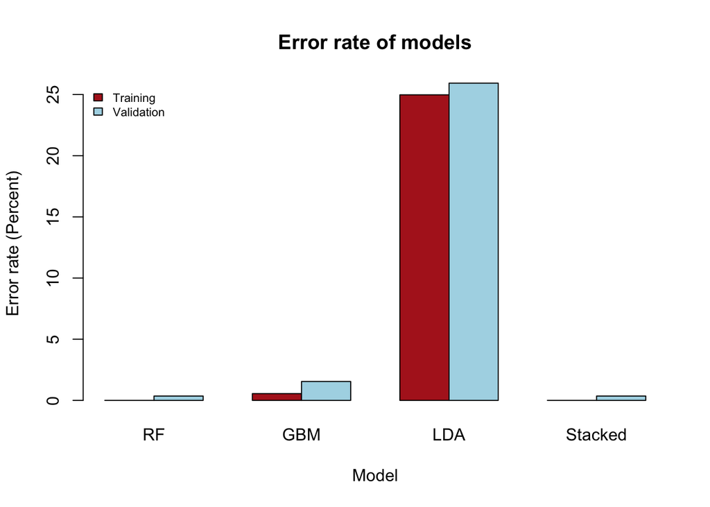

```r
#Convert accuracy to error rate and generate barplots
barplot(100*(1-rbind(trainingAcc,valAcc)),beside=T,
        names=c('RF','GBM','LDA','Stacked'),
        main='Error rate of models',ylab='Error rate (Percent)',
        xlab='Model',col=c('firebrick','lightblue'))

legend('topleft',c('Training','Validation'),
       fill=c('firebrick','lightblue'), bty='n',cex=0.7)
```

As expected, the error rate of every model is higher in the validation set than the training set. This is likely due to overfitting.

### Predict classe for the test data

**The test data were analyzed a single time after concluding that the random forest algorithm is >99% accurate. The code and results are below.**

```r
#Load test data
testData <- read.csv('~/Desktop/Coursera/Practical Machine Learning/pml-testing.csv')

#As the last column is "problem_id" rather than "classe"
#the code has been edited to ensure the processing is identical
#to the training and validation data.
testData <- testData[,-which(colnames(testData) %in% c('X','raw_timestamp_part_1','raw_timestamp_part_2','cvtd_timestamp','new_window','problem_id'))]
testData[,-1] <- apply(testData[,-1],2,as.numeric)
testData[,1] <- factor(testData[,1])

#Z normalize using mean and SD from training set
testing <- NULL
for (i in seq(2,ncol(testData))) {
  testing <- cbind(testing,(testData[,i] - trainingMean[i-1]) / trainingSD[i-1])
}
colnames(testing) <- colnames(testData)[-1]
testing.noNA <- testing[,colSums(is.na(testing)) == 0]
testing.norm <- as.data.frame(testing.noNA)
testing.norm$user_name <- testData$user_name
testing.norm[,-ncol(testing.norm)] <- apply(testing.norm[,-ncol(testing.norm)],2,as.numeric)

#Predicted testing classe
data.frame(problem_id=seq(nrow(testing.norm)),classe=predict(rf,testing.norm))
```

```
##    problem_id classe
## 1           1      B
## 2           2      A
## 3           3      B
## 4           4      A
## 5           5      A
## 6           6      E
## 7           7      D
## 8           8      B
## 9           9      A
## 10         10      A
## 11         11      B
## 12         12      C
## 13         13      B
## 14         14      A
## 15         15      E
## 16         16      E
## 17         17      A
## 18         18      B
## 19         19      B
## 20         20      B
```